# 1826074_오현진

소속 : 소프트웨어학과 학번 : 1826074 성명 : 오현진

7장 : 분류(Classification)

1. weather와 play에 속하는 요소들을 라벨링하는 작업

```python
from sklearn.preprocessing import LabelEncoder

weather = ['Sunny','Sunny','Overcast','Rainy','Rainy',
           'Rainy','Overcast','Sunny','Sunny','Rainy',
           'Sunny','Overcast','Overcast','Rainy']
play =    ['No','No','Yes','Yes','Yes',
           'No','Yes','No','Yes','Yes',
           'Yes','Yes','Yes','No']

le = LabelEncoder()
X = le.fit_transform(weather)
y = le.fit_transform(play)

print(X)
print(y)
```

```
[2 2 0 1 1 1 0 2 2 1 2 0 0 1]
[0 0 1 1 1 0 1 0 1 1 1 1 1 0]
```

1. 가우시안 나이브 베이즈 모델을 통해서 예측하기

```python
from sklearn.naive_bayes import GaussianNB

model = GaussianNB()
model.fit(X.reshape(-1,1), y.reshape(-1,1))

predicted = model.predict([[0]])
print("Predicted Value:", predicted)
```

```
Predicted Value: [1]
```

1. 퍼셉트론을 파이썬으로 직접 구현해보기

   > 학습 부분의 코드를 분석해 주석처리 해보았습니다.

```python
import numpy as np
class Perceptron():
    def __init__(self, eta=0.01, n_iter=50, random_state=1):
        self.eta = eta
        self.n_iter = n_iter
        self.random_state = random_state

    def predict(self, X):
        hyperthesis = np.dot(X, self.w_[1:]) + self.w_[0]
        return np.where(hyperthesis>0.0, 1, -1)

    def fit(self, X, y):
        rgen = np.random.RandomState(self.random_state) # 랜덤 생성
        self.w_ = rgen.normal(loc=0.0, scale=0.01, size=X.shape[1]+1) # x 크기에 따라 normal을 통해 가중치 생성
        self.errors_ = []
        for _ in range(self.n_iter): # 50회 반복학습
            errors = 0
            for features, target in zip(X, y):
                update = self.eta * (target - self.predict(features)) # 학습률과 (정답 - 예측값) 즉, 오차를 곱함
                self.w_[1:] += update * features # 위에서 구한 값으로 가중치 갱신
                self.w_[0] += update
                errors += int(update != 0.0) # 에러 갱신
            self.errors_.append(errors)
        return self # 학습 완료 및 결과 반환
```

1. iris 데이터 준비

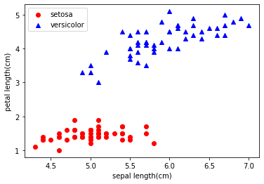

```python
from sklearn.datasets import load_iris
import matplotlib.pyplot as plt

iris = load_iris()

X = iris["data"][0:100, (0,2)]
y = iris["target"][0:100]
y = np.where(y==0, -1, 1)

plt.scatter(X[0:50, 0], X[0:50, 1], color="r", marker="o", label="setosa")
plt.scatter(X[50:100, 0], X[50:100, 1], color="b", marker="^", label="versicolor")

plt.xlabel('sepal length(cm)')
plt.ylabel('petal length(cm)')
plt.legend()

plt.show()
```

1. 구현한 퍼셉트론으로 학습 및 결과 확인

   > 에폭(학습 횟수)이 커질수록 오차의 수가 현저히 적어져 0이 되는 모습을 관찰했습니다.

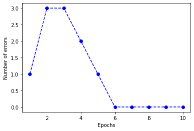

```python
from sklearn.datasets import load_iris
import matplotlib.pyplot as plt

iris = load_iris()

X = iris["data"][0:100, (0,2)]
y = iris["target"][0:100]
y = np.where(y==0, -1, 1)

p = Perceptron(eta=0.1, n_iter=10)
p.fit(X, y)

plt.plot(range(1, len(p.errors_)+1), p.errors_, "bo--")
plt.xlabel('Epochs')
plt.ylabel('Number of errors')

plt.show()
```

1. 결정영역 그리기

   > 두가지 항목에 대한 학습을 한 영역에 표시하는 도구를 실습해보았습니다

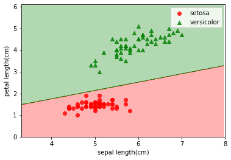

```python
from sklearn.datasets import load_iris
import matplotlib.pyplot as plt
from matplotlib.colors import ListedColormap

def plot_decision_region(X, y, classifier):
    markers = ('o', '^', 'x')
    colors = ('red', 'green', 'blue')
    cmap = ListedColormap(colors[:len(np.unique(y))])
    x_min, x_max = X[:, 0].min()-1, X[:, 0].max()+1
    y_min, y_max = X[:, 1].min()-1, X[:, 1].max()+1
    xx, yy = np.meshgrid(np.arange(x_min, x_max, 0.02), np.arange(y_min, y_max, 0.02))
    Z = classifier.predict(np.array([xx.ravel(), yy.ravel()]).T)
    Z = Z.reshape(xx.shape)
    plt.contourf(xx, yy, Z, alpha=0.3, cmap=cmap)
    plt.axis([x_min, x_max, y_min, y_max])
    for idx, target in enumerate(np.unique(y)):
        plt.scatter(X[y==target, 0], X[y==target, 1],
                    alpha=0.8, c=colors[idx], marker=markers[idx],
                    label=np.where(target==-1, 'setosa', 'versicolor'))

iris = load_iris()
X = iris["data"][0:100, (0,2)]
y = iris["target"][0:100]
y = np.where(y==0, -1, 1)

plot_decision_region(X, y, classifier=p)
plt.xlabel('sepal length(cm)')
plt.ylabel('petal length(cm)')
plt.legend()

plt.show()
```

1. sklearn에 구현된 퍼셉트론 사용해보기

```python
from sklearn.datasets import load_iris
from sklearn.linear_model import Perceptron
from sklearn.model_selection import train_test_split
from sklearn.metrics import accuracy_score

iris = load_iris()
X = iris["data"][0:100, (0,2)]
y = iris["target"][0:100]
y = np.where(y==0, -1, 1)

X_train, X_test, y_train, y_test = train_test_split(X, y, test_size=0.3)
ppn = Perceptron(eta0=0.1, max_iter=30, random_state=1)
ppn.fit(X_train, y_train)
y_pred = ppn.predict(X_test)

print(f"accuracy: {accuracy_score(y_test, y_pred)}")
```

```
accuracy: 1.0
```

1. iris 데이터 준비

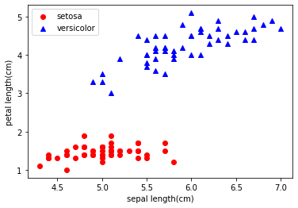

```python
from sklearn.datasets import load_iris
import matplotlib.pyplot as plt

iris = load_iris()
X = iris["data"][0:100, (0,2)]
y = iris["target"][0:100]
y = np.where(y==0, -1, 1)

plt.scatter(X[0:50, 0], X[0:50, 1], color="r", marker="o", label="setosa")
plt.scatter(X[50:100, 0], X[50:100, 1], color="b", marker="^", label="versicolor")

plt.xlabel('sepal length(cm)')
plt.ylabel('petal length(cm)')
plt.legend()
plt.show()
```

1. 이진 분류기 사용해보기

```
accuracy: 1.0
```

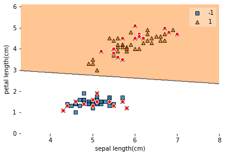

```python
from sklearn.linear_model import LogisticRegression
from mlxtend.plotting import plot_decision_regions

X_train, X_test, y_train, y_test = train_test_split(X, y, test_size=0.3)

model = LogisticRegression()
model.fit(X_train, y_train)
y_pred = model.predict(X_test)
print(f"accuracy: {accuracy_score(y_test, y_pred)}")

plot_decision_regions(X, y, clf=model)
plt.scatter(X_test[:,0], X_test[:,1], marker="o", color="r", edgecolor="w")
plt.xlabel('sepal length(cm)')
plt.ylabel('petal length(cm)')

plt.show()
```

1. iris 데이터 전체 확인

```python
from sklearn.datasets import load_iris
import pandas as pd

iris = load_iris()
df = pd.DataFrame(iris.data, columns=iris.feature_names)
df['target'] = iris.target
df
```

|  | sepal length (cm) | sepal width (cm) | petal length (cm) | petal width (cm) | target |
| --- | --- | --- | --- | --- | --- |
| 0 | 5.1 | 3.5 | 1.4 | 0.2 | 0 |
| 1 | 4.9 | 3.0 | 1.4 | 0.2 | 0 |
| 2 | 4.7 | 3.2 | 1.3 | 0.2 | 0 |
| 3 | 4.6 | 3.1 | 1.5 | 0.2 | 0 |
| 4 | 5.0 | 3.6 | 1.4 | 0.2 | 0 |
| ... | ... | ... | ... | ... | ... |
| 145 | 6.7 | 3.0 | 5.2 | 2.3 | 2 |
| 146 | 6.3 | 2.5 | 5.0 | 1.9 | 2 |
| 147 | 6.5 | 3.0 | 5.2 | 2.0 | 2 |
| 148 | 6.2 | 3.4 | 5.4 | 2.3 | 2 |
| 149 | 5.9 | 3.0 | 5.1 | 1.8 | 2 |

150 rows × 5 columns

1. iris 데이터 중 일부 데이터 추출

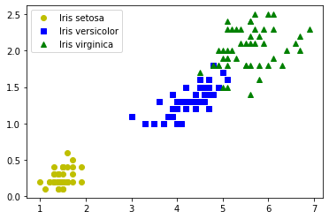

```python
from sklearn.datasets import load_iris
import matplotlib.pyplot as plt

iris = load_iris()
X = iris["data"][:, (2,3)]
y = iris["target"]
plt.plot(X[y==0, 0], X[y==0, 1], "yo", label="Iris setosa")
plt.plot(X[y==1, 0], X[y==1, 1], "bs", label="Iris versicolor")
plt.plot(X[y==2, 0], X[y==2, 1], "g^", label="Iris virginica")

plt.legend()
plt.show()
```

```python
from sklearn.datasets import load_iris
from sklearn.linear_model import LogisticRegression
from sklearn import model_selection
from sklearn import metrics

iris = load_iris()
X = iris["data"][:, (2,3)]
y = iris["target"]

X_train, X_test, y_train, y_test = model_selection.train_test_split(X, y, test_size=0.3)
softmax_reg = LogisticRegression(multi_class="multinomial", C=1, penalty='l2')
softmax_reg.fit(X_train, y_train)
y_predict = softmax_reg.predict(X_test)
score = metrics.r2_score(y_test, y_predict)

print(f"accuracy = {score}")
```

```
accuracy = 0.875
```

1. MinMaxScaler 사용해보기

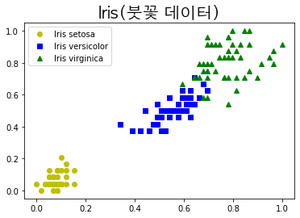

```python
from sklearn.datasets import load_iris
import matplotlib.pyplot as plt
from sklearn.preprocessing import MinMaxScaler

iris = load_iris()
x_data = iris["data"][:, (2,3)]
scaler = MinMaxScaler()
scaler.fit(x_data)

X = scaler.transform(x_data)
y = iris["target"]
plt.title("Iris(붓꽃 데이터)", fontsize=20, fontfamily = "AppleGothic")

plt.plot(X[y==0, 0], X[y==0, 1], "yo", label="Iris setosa")
plt.plot(X[y==1, 0], X[y==1, 1], "bs", label="Iris versicolor")
plt.plot(X[y==2, 0], X[y==2, 1], "g^", label="Iris virginica")

plt.legend()
plt.show()
```

1. 스토캐스틱 경사 하강법 알고리즘을 이용한 분류

```
[1]
```

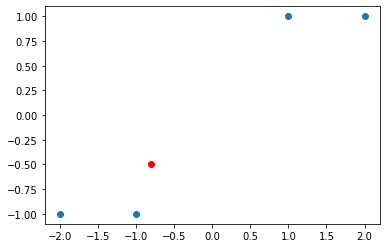

```python
from sklearn.linear_model import SGDClassifier
import matplotlib.pyplot as plt

X = np.array([[-1, -1], [-2, -1], [1, 1], [2, 1]])
y = np.array([1, 1, 2, 2])

clf = SGDClassifier(max_iter=1000, tol=1e-3)
clf.fit(X, y)
print(clf.predict([[-0.8, -0.5]]))

plt.scatter(X[:,0], X[:,1])
plt.scatter(-0.8, -0.5, marker="o", color="r")
plt.show()
```

1. Digits 데이터 셋 확인

```
(1797, 64) (1797,)
```

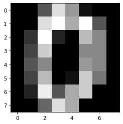

```python
import numpy as np
from sklearn import datasets

digits = datasets.load_digits()
X, y = digits.data, digits.target
print(X.shape, y.shape)

first_digit = X[0]
first_digit_image = first_digit.reshape(8, 8)
plt.imshow(first_digit_image, cmap="gray")

plt.show()
```

1. 스토캐스틱 경사 하강법을 이용한 학습 정확도 확인

```python
from sklearn import datasets
from sklearn.model_selection import train_test_split
from sklearn.linear_model import SGDClassifier
from sklearn.metrics import accuracy_score
import numpy as np
import matplotlib.pyplot as plt

digits = datasets.load_digits()
X, y = digits.data, digits.target
X_train, X_test, y_train, y_test = train_test_split(X, y, test_size=0.3)

model = SGDClassifier()
model.fit(X_train, y_train)
y_pred = model.predict(X_test)

print(f"accuracy: {accuracy_score(y_test, y_pred)}")
```

```
accuracy: 0.9611111111111111
```

1. MNIST 데이터셋에 대해 스토캐스틱 경사 하강법을 이용한 학습 정확도 확인

   > MNIST의 경우 실행 시간이 너무 길고 렉이 걸려서 실행은 못해보았습니다!

```python
from sklearn.datasets import fetch_openml
mnist = fetch_openml('mnist_784')
mnist.keys()
```

```python
import numpy as np
import matplotlib.pyplot as plt
X, y = mnist.data, mnist.target
print(X.shape, y.shape)
first_digit = np.array(X.iloc[0,:].tolist())
first_digit_image = first_digit.reshape(28, 28)
plt.imshow(first_digit_image, cmap="gray")

plt.show()
```

```python
from sklearn.datasets import fetch_openml
mnist = fetch_openml('mnist_784')
X, y = mnist.data, mnist.target
```

```python
from sklearn.model_selection import train_test_split
from sklearn.linear_model import SGDClassifier
from sklearn.metrics import accuracy_score
import numpy as np
import matplotlib.pyplot as plt

X_train, X_test, y_train, y_test = train_test_split(X, y, test_size=0.3)
model = SGDClassifier()
model.fit(X_train, y_train)
y_pred = model.predict(X_test)

print(f"accuracy: {accuracy_score(y_test, y_pred)}")
```

8장 : SVM과 결정트리

1. numpy를 통한 svm 구현

```python
class SVM:
    def __init__(self, X, y, epochs, lr, C):
        self.X = X; self.y = y; self.epochs = epochs
        self.lr = lr; self.C = C
        self.X = np.column_stack((np.ones(len(X)), X))
        self.w = np.ones(len(self.X[0]))

    def distances(self, w, with_lagrange=True):
        distances = self.y * (np.dot(self.X, w)) - 1
        if with_lagrange:
            distances[distances > 0] = 0
        return distances

    def get_cost_grads(self, X, w, y):
        distances = self.distances(w)
        L = 1 / 2 * np.dot(w, w) - self.C * np.sum(distances)
        dw = np.zeros(len(w))

        for ind, d in enumerate(distances):
            if d == 0:
                di = w
            else:
                di = w - (self.C * y[ind] * X[ind])
            dw += di
            return L, dw / len(X)
    def fit(self):
        for i in range(self.epochs):
            L, dw = self.get_cost_grads(self.X, self.w, self.y)
            self.w = self.w - self.lr * dw
    def predict(self, X):
        X = np.column_stack((np.ones(len(X)), X))
        return np.sign(X @ self.w)
```

1. 소프트 벡터 분류 실습

```
accuracy: 1.0
```

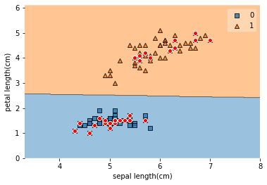

```python
from sklearn.model_selection import train_test_split
from sklearn.svm import SVC
from sklearn.metrics import accuracy_score
from mlxtend.plotting import plot_decision_regions
import matplotlib.pyplot as plt

iris = load_iris()
X = iris["data"][0:100, (0,2)]
y = iris["target"][0:100]
y = np.where(y==0, 0, 1)

X_train, X_test, y_train, y_test = train_test_split(X, y, test_size=0.3)
clf = SVC(kernel='linear', C=0.5)
clf.fit(X_train, y_train)
y_pred = clf.predict(X_test)
print(f"accuracy: {accuracy_score(y_test, y_pred)}")

plot_decision_regions(X, y, clf=clf)
plt.scatter(X_test[:,0], X_test[:,1], marker="o", color="r", edgecolor="w")
plt.xlabel('sepal length(cm)')
plt.ylabel('petal length(cm)')

plt.show()
```

1. make_moons를 이용한 비선형 SVM 분류

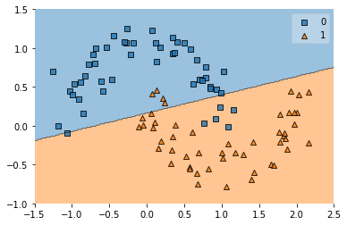

```python
from sklearn.datasets import make_moons
from sklearn.preprocessing import StandardScaler
from sklearn.pipeline import make_pipeline
from mlxtend.plotting import plot_decision_regions
import matplotlib.pyplot as plt

X, y = make_moons(n_samples=100, noise=0.15)
svm_clf = make_pipeline(StandardScaler(), SVC(kernel='linear', C=10))
svm_clf.fit(X, y)

plot_decision_regions(X, y, clf=svm_clf)
plt.axis([-1.5, 2.5, -1.0, 1.5])

plt.show()
```

1. Polynomial Features를 이용한 다항 회귀

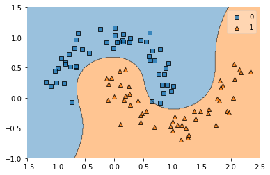

```python
from sklearn.datasets import make_moons
from sklearn.preprocessing import PolynomialFeatures
from sklearn.preprocessing import StandardScaler
from sklearn.pipeline import make_pipeline
from mlxtend.plotting import plot_decision_regions
import matplotlib.pyplot as plt

X, y = make_moons(n_samples=100, noise=0.15)
svm_clf = make_pipeline(PolynomialFeatures(degree=3), StandardScaler(), SVC(kernel='linear', C=10))
svm_clf.fit(X, y)

plot_decision_regions(X, y, clf=svm_clf)
plt.axis([-1.5, 2.5, -1.0, 1.5])

plt.show()
```

1. 다항식 커널을 이용한 커널 트릭이 적용된 비선형 SVM

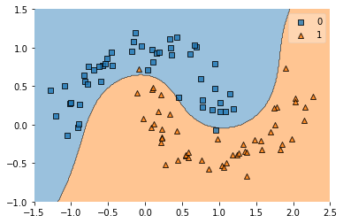

```python
from sklearn.datasets import make_moons
from sklearn.preprocessing import StandardScaler
from sklearn.pipeline import make_pipeline
from mlxtend.plotting import plot_decision_regions
import matplotlib.pyplot as plt

X, y = make_moons(n_samples=100, noise=0.15)
svm_clf = make_pipeline(StandardScaler(), SVC(kernel='poly', degree=3, coef0=1, C=5))
svm_clf.fit(X, y)

plot_decision_regions(X, y, clf=svm_clf)
plt.axis([-1.5, 2.5, -1.0, 1.5])

plt.show()
```

1. RBF 커널을 이용한 비선형 SVM

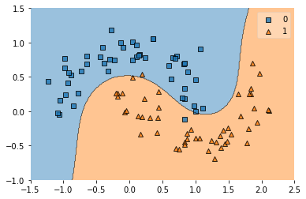

```python
from sklearn.datasets import make_moons
from sklearn.preprocessing import StandardScaler
from sklearn.pipeline import make_pipeline
from mlxtend.plotting import plot_decision_regions
import matplotlib.pyplot as plt

X, y = make_moons(n_samples=100, noise=0.15)
svm_clf = make_pipeline(StandardScaler(), SVC(kernel='rbf', gamma=0.1, C=100))
svm_clf.fit(X, y)

plot_decision_regions(X, y, clf=svm_clf)
plt.axis([-1.5, 2.5, -1.0, 1.5])

plt.show()
```

1. 결정트리의 시각화

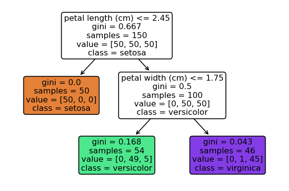

```python
from sklearn.datasets import load_iris
from sklearn.tree import DecisionTreeClassifier
from sklearn.tree import plot_tree
import matplotlib.pyplot as plt

iris = load_iris()
X = iris.data[:, 2:]
y = iris.target

clf = DecisionTreeClassifier(max_depth=2)
clf.fit(X, y)
plt.figure(dpi=120)

plot_tree(clf, feature_names=iris.feature_names[2:],
class_names=iris.target_names, filled=True, rounded=True)

plt.show()
```

9장 : 앙상블과 랜덤포레스트

1. 보팅을 적용할 데이터 준비

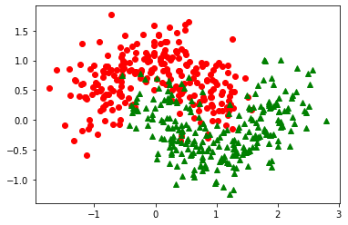

```python
from sklearn.datasets import make_moons
import matplotlib.pyplot as plt

X, y = make_moons(n_samples=500, noise=0.30, random_state=42)
plt.plot(X[:, 0][y==0], X[:, 1][y==0], "ro")
plt.plot(X[:, 0][y==1], X[:, 1][y==1], "g^")

plt.show()
```

```python
from sklearn.ensemble import RandomForestClassifier
from sklearn.linear_model import LogisticRegression
from sklearn.svm import SVC
from sklearn.ensemble import VotingClassifier
from sklearn.metrics import accuracy_score

log_clf = LogisticRegression()
rnd_clf = RandomForestClassifier(n_estimators=10)
svm_clf = SVC()

models = [('lr', log_clf), ('rf', rnd_clf), ('svm', svm_clf)]
voting_clf = VotingClassifier(estimators=models, voting='hard')
voting_clf.fit(X_train, y_train)

for clf in (log_clf, rnd_clf, svm_clf, voting_clf):
    clf.fit(X_train, y_train)
    y_pred = clf.predict(X_test)
    print(clf.__class__.__name__, accuracy_score(y_test,y_pred))
```

```
LogisticRegression 1.0
RandomForestClassifier 1.0
SVC 1.0
VotingClassifier 1.0
```

```python
from sklearn.ensemble import RandomForestClassifier
from sklearn.linear_model import LogisticRegression
from sklearn.svm import SVC
from sklearn.ensemble import VotingClassifier
from sklearn.metrics import accuracy_score

log_clf = LogisticRegression()
rnd_clf = RandomForestClassifier(n_estimators=10)
svm_clf = SVC(probability=True)

models = [('lr', log_clf), ('rf', rnd_clf), ('svm', svm_clf)]
voting_clf = VotingClassifier(estimators=models, voting='soft')
voting_clf.fit(X_train, y_train)

for clf in (log_clf, rnd_clf, svm_clf, voting_clf):
    clf.fit(X_train, y_train)
    y_pred = clf.predict(X_test)
    print(clf.__class__.__name__, accuracy_score(y_test,y_pred))
```

```
LogisticRegression 1.0
RandomForestClassifier 1.0
SVC 1.0
VotingClassifier 1.0
```

1. iris 데이터 준비

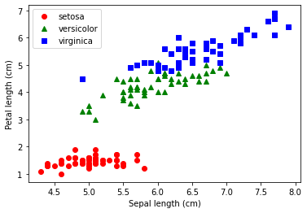

```python
from sklearn.datasets import load_iris
import matplotlib.pyplot as plt

iris = load_iris()
X = iris.data[:, [0, 2]]
y = iris.target

plt.plot(X[:,0][y==0], X[:,1][y==0], "ro", label='setosa')
plt.plot(X[:,0][y==1], X[:,1][y==1], "g^", label='versicolor')
plt.plot(X[:,0][y==2], X[:,1][y==2], "bs", label='virginica')

plt.xlabel('Sepal length (cm)')
plt.ylabel('Petal length (cm)')
plt.legend()

plt.show()
```

1. iris 데이터에 대한 Voting 적용

```python
from sklearn.tree import DecisionTreeClassifier
from sklearn.neighbors import KNeighborsClassifier
from sklearn.svm import SVC
from sklearn.ensemble import VotingClassifier
from sklearn.metrics import accuracy_score

X_train, X_test, y_train, y_test = train_test_split(X, y)
dt_clf = DecisionTreeClassifier(max_depth=4)
knn_clf = KNeighborsClassifier(n_neighbors=7)
svm_clf = SVC(gamma=0.1, probability=True)

models = [('dt', dt_clf), ('knn', knn_clf), ('svm', svm_clf)]
voting_clf = VotingClassifier(models, voting='soft', weights=[2, 1, 2])
voting_clf.fit(X_train, y_train)

for clf in (dt_clf, knn_clf, svm_clf, voting_clf):
    clf.fit(X_train, y_train)
    y_pred = clf.predict(X_test)
    print(f"{clf.__class__.__name__}: {accuracy_score(y_test,y_pred):.4f}")
```

```
DecisionTreeClassifier: 0.8947
KNeighborsClassifier: 0.9474
SVC: 0.9474
VotingClassifier: 0.9474
```

1. Bagging에 사용될 iris 데이터 준비

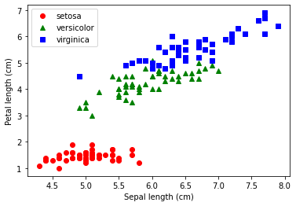

```python
from sklearn.datasets import load_iris
import matplotlib.pyplot as plt

iris = load_iris()
X = iris.data[:, [0, 2]]
y = iris.target

plt.plot(X[:,0][y==0], X[:,1][y==0], "ro", label='setosa')
plt.plot(X[:,0][y==1], X[:,1][y==1], "g^", label='versicolor')
plt.plot(X[:,0][y==2], X[:,1][y==2], "bs", label='virginica')

plt.xlabel('Sepal length (cm)')
plt.ylabel('Petal length (cm)')
plt.legend()

plt.show()
```

1. 주어진 데이터에 대해 Bagging 수행

```python
from sklearn.ensemble import BaggingClassifier
from sklearn.tree import DecisionTreeClassifier

dt_clf = DecisionTreeClassifier()
bag_clf = BaggingClassifier(dt_clf, n_estimators=500)
bag_clf.fit(X_train, y_train)

for clf in (dt_clf, bag_clf):
    clf.fit(X_train, y_train)
    y_pred = clf.predict(X_test)
    print(f"{clf.__class__.__name__}: \
        {accuracy_score(y_test,y_pred):.4f}")
```

```
DecisionTreeClassifier:         0.8947
BaggingClassifier:         0.9211
```

1. make_moons 데이터 준비

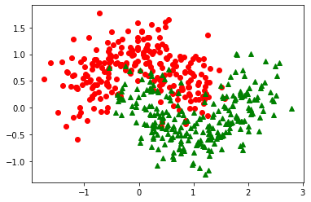

```python
from sklearn.datasets import make_moons
import matplotlib.pyplot as plt

X, y = make_moons(n_samples=500, noise=0.30, random_state=42)
plt.plot(X[:, 0][y==0], X[:, 1][y==0], "ro")
plt.plot(X[:, 0][y==1], X[:, 1][y==1], "g^")

plt.show()
```

1. 주어진 데이터에 대해 Bagging 수행

```python
from sklearn.datasets import make_moons
from sklearn.model_selection import train_test_split
from sklearn.tree import DecisionTreeClassifier
from sklearn.ensemble import BaggingClassifier
from sklearn.metrics import accuracy_score

X, y = make_moons(n_samples=500, noise=0.30, random_state=42)
X_train, X_test, y_train, y_test = train_test_split(X, y)
dt_clf = DecisionTreeClassifier()
bag_clf = BaggingClassifier(dt_clf, n_estimators=500)
bag_clf.fit(X_train, y_train)

for clf in (dt_clf, bag_clf):
    clf.fit(X_train, y_train)
    y_pred = clf.predict(X_test)
    print(f"{clf.__class__.__name__}: \
    {accuracy_score(y_test,y_pred):.4f}")
```

```
DecisionTreeClassifier:     0.8560
BaggingClassifier:     0.9040
```

1. 랜덤 포레스트 방법 수행

```python
from sklearn.datasets import make_moons
from sklearn.model_selection import train_test_split
from sklearn.ensemble import RandomForestClassifier
from sklearn.metrics import accuracy_score

X, y = make_moons(n_samples=500, noise=0.30, random_state=42)
X_train, X_test, y_train, y_test = train_test_split(X, y)

clf = RandomForestClassifier(n_estimators=500)
clf.fit(X_train, y_train)
y_pred = clf.predict(X_test)

print(f"{clf.__class__.__name__}: {accuracy_score(y_test,y_pred):.4f}")
```

```
RandomForestClassifier: 0.8880
```

1. 에이다 부스트를 이용한 학습

```python
from sklearn.datasets import make_moons
from sklearn.model_selection import train_test_split
from sklearn.ensemble import AdaBoostClassifier
from sklearn.metrics import accuracy_score

X, y = make_moons(n_samples=500, noise=0.30, random_state=42)
X_train, X_test, y_train, y_test = train_test_split(X, y)

clf = AdaBoostClassifier(n_estimators=200, learning_rate=0.1)
clf.fit(X_train, y_train)
y_pred = clf.predict(X_test)

print(f"{clf.__class__.__name__}: {accuracy_score(y_test,y_pred):.4f}")
```

```
AdaBoostClassifier: 0.8960
```

1. GBM을 이용한 학습

```python
from sklearn.datasets import make_moons
from sklearn.model_selection import train_test_split
from sklearn.ensemble import GradientBoostingClassifier
from sklearn.metrics import accuracy_score

X, y = make_moons(n_samples=500, noise=0.30, random_state=42)
X_train, X_test, y_train, y_test = train_test_split(X, y)

clf = GradientBoostingClassifier(n_estimators=200, learning_rate=0.1)
clf.fit(X_train, y_train)
y_pred = clf.predict(X_test)

print(f"{clf.__class__.__name__}:{accuracy_score(y_test,y_pred):.4f}")
```

```
GradientBoostingClassifier:0.9120
```

1. XGB를 이용한 학습

```python
import warnings
warnings.filterwarnings(action='ignore')

from sklearn.datasets import make_moons
from sklearn.model_selection import train_test_split
from xgboost import XGBClassifier
from sklearn.metrics import accuracy_score

X, y = make_moons(n_samples=500, noise=0.30, random_state=42)
X_train, X_test, y_train, y_test = train_test_split(X, y)

clf = XGBClassifier(n_estimators=200, learning_rate=0.1)
clf.fit(X_train, y_train)
y_pred = clf.predict(X_test)

print(f"{clf.__class__.__name__}: {accuracy_score(y_test,y_pred):.4f}")
```

```
XGBClassifier: 0.8880
```

1. LGBM을 이용한 학습

   > 확인 결과 MacOS 환경에서는 lightgbm을 사용하기 어려운 것 같습니다!

```python
import warnings
warnings.filterwarnings(action='ignore')
from sklearn.datasets import make_moons
from sklearn.model_selection import train_test_split
from lightgbm import LGBMClassifier
from sklearn.metrics import accuracy_score

X, y = make_moons(n_samples=500, noise=0.30, random_state=42)
X_train, X_test, y_train, y_test = train_test_split(X, y)

clf = LGBMClassifier(n_estimators=200, learning_rate=0.1)
clf.fit(X_train, y_train)
y_pred = clf.predict(X_test)

print(f"{clf.__class__.__name__}:{accuracy_score(y_test,y_pred):.4f}")
```

[output not shown]

10장 : PCA와 비지도학습

1. iris 데이터에 대한 정규화

```python
from sklearn.datasets import load_iris
from sklearn.preprocessing import StandardScaler
import pandas as pd

iris = load_iris()
X = StandardScaler().fit_transform(iris.data)
y = iris.target
df = pd.DataFrame(X, columns=['sepal length','sepal width','petal length','petal width'])
df['target']=y

df
```

|  | sepal length | sepal width | petal length | petal width | target |
| --- | --- | --- | --- | --- | --- |
| 0 | -0.900681 | 1.019004 | -1.340227 | -1.315444 | 0 |
| 1 | -1.143017 | -0.131979 | -1.340227 | -1.315444 | 0 |
| 2 | -1.385353 | 0.328414 | -1.397064 | -1.315444 | 0 |
| 3 | -1.506521 | 0.098217 | -1.283389 | -1.315444 | 0 |
| 4 | -1.021849 | 1.249201 | -1.340227 | -1.315444 | 0 |
| ... | ... | ... | ... | ... | ... |
| 145 | 1.038005 | -0.131979 | 0.819596 | 1.448832 | 2 |
| 146 | 0.553333 | -1.282963 | 0.705921 | 0.922303 | 2 |
| 147 | 0.795669 | -0.131979 | 0.819596 | 1.053935 | 2 |
| 148 | 0.432165 | 0.788808 | 0.933271 | 1.448832 | 2 |
| 149 | 0.068662 | -0.131979 | 0.762758 | 0.790671 | 2 |

150 rows × 5 columns

1. iris에 대한 PCA 기법 적용

```python
from sklearn.datasets import load_iris
from sklearn.preprocessing import StandardScaler
from sklearn.decomposition import PCA
import pandas as pd

iris = load_iris()
X = StandardScaler().fit_transform(iris.data)
y = iris.target

pca = PCA(n_components=2)
pca_X = pca.fit_transform(X)
df = pd.DataFrame(pca_X, columns=['feature 1', 'feature 2'])

df
```

|  | feature 1 | feature 2 |
| --- | --- | --- |
| 0 | -2.264703 | 0.480027 |
| 1 | -2.080961 | -0.674134 |
| 2 | -2.364229 | -0.341908 |
| 3 | -2.299384 | -0.597395 |
| 4 | -2.389842 | 0.646835 |
| ... | ... | ... |
| 145 | 1.870503 | 0.386966 |
| 146 | 1.564580 | -0.896687 |
| 147 | 1.521170 | 0.269069 |
| 148 | 1.372788 | 1.011254 |
| 149 | 0.960656 | -0.024332 |

150 rows × 2 columns

1. PCA 결과에 대한 시각화 적용

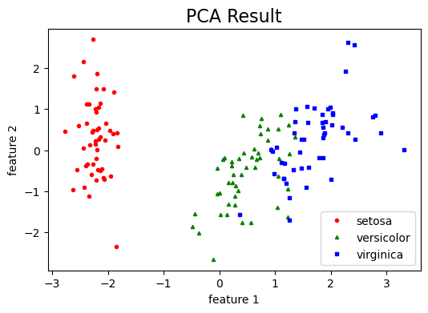

```python
import matplotlib.pyplot as plt

plt.figure(dpi=100)
plt.title('PCA Result', fontsize=16)

plt.plot(pca_X[:,0][y==0], pca_X[:,1][y==0],
             "ro", markersize=3, label='setosa')
plt.plot(pca_X[:,0][y==1], pca_X[:,1][y==1],
             "g^", markersize=3, label='versicolor')
plt.plot(pca_X[:,0][y==2], pca_X[:,1][y==2],
             "bs", markersize=3, label='virginica')
plt.xlabel('feature 1')
plt.ylabel('feature 2')
plt.legend()

plt.show()
```

1. kmeans 알고리즘을 적용하기 위한 iris데이터 준비

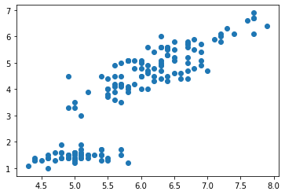

```python
from sklearn.datasets import load_iris
import matplotlib.pyplot as plt

iris = load_iris()
X = iris["data"][:, (0,2)]

plt.scatter(X[:,0], X[:,1])
plt.show()
```

1. k를 3으로 설정하였을 경우의 kmeans 알고리즘 적용결과

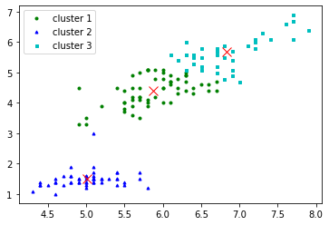

```python
from sklearn.datasets import load_iris
from sklearn.cluster import KMeans
import matplotlib.pyplot as plt

iris = load_iris()
X = iris["data"][:, (0,2)]

kmeans = KMeans(n_clusters=3)
y = kmeans.fit_predict(X)
C = kmeans.cluster_centers_

plt.plot(X[:,0][y==0], X[:,1][y==0], "go", label="cluster 1", markersize=3)
plt.plot(X[:,0][y==1], X[:,1][y==1], "b^", label="cluster 2", markersize=3)
plt.plot(X[:,0][y==2], X[:,1][y==2], "cs", label="cluster 3", markersize=3)
plt.plot(C[:,0], C[:,1], "rx", markersize=10)
plt.legend()

plt.show()
```

1. k를 5로 설정하였을 경우의 kmeans 알고리즘 적용결과

   > 클러스터 수에 따른 결과 차이를 확인하였습니다.

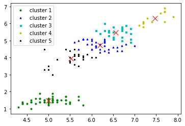

```python
from sklearn.datasets import load_iris
from sklearn.cluster import KMeans
import matplotlib.pyplot as plt

iris = load_iris()
X = iris["data"][:, (0,2)]

kmeans = KMeans(n_clusters=5)
y = kmeans.fit_predict(X)
C = kmeans.cluster_centers_

plt.plot(X[:,0][y==0], X[:,1][y==0], "go", label="cluster 1", markersize=3)
plt.plot(X[:,0][y==1], X[:,1][y==1], "b^", label="cluster 2", markersize=3)
plt.plot(X[:,0][y==2], X[:,1][y==2], "cs", label="cluster 3", markersize=3)
plt.plot(X[:,0][y==3], X[:,1][y==3], "yo", label="cluster 4", markersize=3)
plt.plot(X[:,0][y==4], X[:,1][y==4], "k*", label="cluster 5", markersize=3)
plt.plot(C[:,0], C[:,1], "rx", markersize=10)
plt.legend()

plt.show()
```

1. 실루엣 점수를 확인하는 2가지 예제

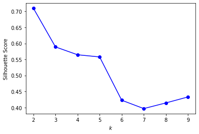

```python
from sklearn.datasets import load_iris
from sklearn.cluster import KMeans
from sklearn.metrics import silhouette_score
import matplotlib.pyplot as plt

iris = load_iris()
X = iris["data"][:, (0,2)]

kmeans_per_k = [KMeans(n_clusters=k).fit(X)
                for k in range(2, 10)]
s_scores = [silhouette_score(X, m.labels_)
            for m in kmeans_per_k]

plt.plot(range(2, 10), s_scores, "bo-")
plt.xlabel("$k$")
plt.ylabel("Silhouette Score")

plt.show()
```

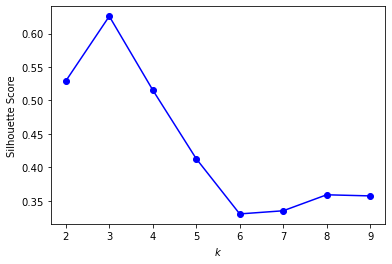

```python
from sklearn.datasets import make_blobs
from sklearn.cluster import KMeans
from sklearn.metrics import silhouette_score
import matplotlib.pyplot as plt

X, y = make_blobs(n_samples=200, n_features=2, centers=3, cluster_std=0.7, random_state=0)
kmeans_per_k = [KMeans(n_clusters=k).fit(X)
                    for k in range(2, 10)]
s_scores = [silhouette_score(X, m.labels_)
            for m in kmeans_per_k]

plt.plot(range(2, 10), s_scores, "bo-")
plt.xlabel("$k$")
plt.ylabel("Silhouette Score")

plt.show()
```

1. MeanShift 알고리즘 수행하기

```
cluster labels : [0 1 2]
[[ 1.78436594  0.82059933]
 [ 0.93390739  4.38280396]
 [-1.51114621  2.68467011]]
```

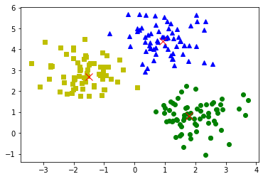

```python
from sklearn.datasets import make_blobs
from sklearn.cluster import MeanShift
import numpy as np
import matplotlib.pyplot as plt

X, y = make_blobs(n_samples=200, n_features=2, centers=3, cluster_std=0.7, random_state=0)
mean_shift = MeanShift(bandwidth=1.0)
labels = mean_shift.fit_predict(X)

print('cluster labels :', np.unique(labels))
C = mean_shift.cluster_centers_
print(C)

plt.plot(X[:,0][labels==0], X[:,1][labels==0], "go")
plt.plot(X[:,0][labels==1], X[:,1][labels==1], "b^")
plt.plot(X[:,0][labels==2], X[:,1][labels==2], "ys")
plt.plot(C[:,0], C[:,1], "rx", markersize=10)

plt.show()
```

1. GVM 수행

```python
import numpy as np
from sklearn.mixture import GaussianMixture

X = np.array([[1, 2], [1, 4], [1, 0], [10, 2], [10, 4], [10, 0]])
gm = GaussianMixture(n_components=2, random_state=0).fit(X)

print(gm.means_)
print(gm.covariances_)
```

```
[[10.  2.]
 [ 1.  2.]]
[[[1.00000000e-06 1.20958672e-29]
  [1.20958672e-29 2.66666767e+00]]

 [[1.00000000e-06 1.24902977e-30]
  [1.24902977e-30 2.66666767e+00]]]
```

1. make_blobs 데이터에 대한 GVM 수행결과

```
cluster labels : [0 1 2]
[[ 0.95995969  4.43266216]
 [ 1.98952065  0.80683533]
 [-1.65934006  2.89402567]]
```

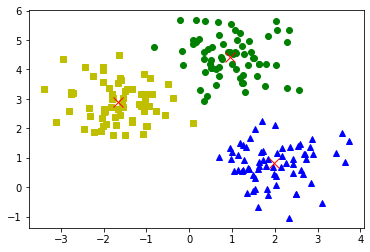

```python
from sklearn.datasets import make_blobs
from sklearn.mixture import GaussianMixture
import numpy as np
import matplotlib.pyplot as plt

X, y = make_blobs(n_samples=200, n_features=2, centers=3, cluster_std=0.7, random_state=0)
gmm = GaussianMixture(n_components=3)
labels = gmm.fit_predict(X)
print('cluster labels :', np.unique(labels))

C = gmm.means_
print(C)

plt.plot(X[:,0][labels==0], X[:,1][labels==0], "go")
plt.plot(X[:,0][labels==1], X[:,1][labels==1], "b^")
plt.plot(X[:,0][labels==2], X[:,1][labels==2], "ys")
plt.plot(C[:,0], C[:,1], "rx", markersize=10)

plt.show()
```